# **Programming Assignment 2**

## Question 1: MNIST Feature Extraction and Classification (50 Points Total)

### **Objective**

In this question, you will explore **feature extraction** and **image classification** using the **MNIST handwritten digit dataset**. Your task is to preprocess raw image data, apply the **2D Discrete Cosine Transform (DCT)**, extract directionally informative coefficients using **frequency masks**, and conduct **dimensionality reduction via eigen decomposition**. You will then use the resulting features to train and compare multiple **classification algorithms**, including traditional machine learning and deep learning approaches.

- **Dataset:** [MNIST Handwritten Digit Dataset](https://www.openml.org/d/554)
- **Focus Areas:** **Signal-based feature engineering**, **dimensionality reduction**, **supervised classification**, and **model comparison**.

### Code

```python
# Question 1: MNIST Feature Extraction and Classification

import numpy as np
import matplotlib.pyplot as plt
from sklearn.datasets import fetch_openml
from sklearn.model_selection import train_test_split
from sklearn.preprocessing import StandardScaler
from sklearn.ensemble import RandomForestClassifier
from sklearn.metrics import accuracy_score, confusion_matrix, ConfusionMatrixDisplay
from scipy.fft import dct
import torch
import torch.nn as nn
import torch.optim as optim
from torch.utils.data import DataLoader, TensorDataset
from cvxopt import matrix, solvers
import time
import warnings
warnings.filterwarnings('ignore')
solvers.options['show_progress'] = False


class MNISTFeatureExtraction:
    """MNIST classification using DCT-based feature extraction and eigen decomposition"""

    def __init__(self, n_samples_per_class=100, n_eigenvectors=20, verbose=True):
        self.n_samples_per_class = n_samples_per_class
        self.n_eigenvectors = n_eigenvectors
        self.verbose = verbose

    def load_data(self):
        if self.verbose:
            print("=" * 60)
            print("PART 1: PREPROCESSING AND VISUALIZATION")
            print("=" * 60)

        mnist = fetch_openml('mnist_784', version=1, as_frame=False)
        self.X_full = mnist.data
        self.y_full = mnist.target.astype(int)

        if self.verbose:
            print(f"\nDataset Structure:")
            print(f"  Total observations: {len(self.X_full)}")
            print(f"  Features per image: {self.X_full.shape[1]} (flattened 28x28)")
            print(f"  Classes: 0-9 (handwritten digits)")

        indices = []
        for digit in range(10):
            digit_indices = np.where(self.y_full == digit)[0]
            sampled = np.random.choice(digit_indices, self.n_samples_per_class, replace=False)
            indices.extend(sampled)

        np.random.shuffle(indices)
        self.X = self.X_full[indices]
        self.y = self.y_full[indices]

        if self.verbose:
            print(f"\nSampled Dataset:")
            print(f"  Observations: {len(self.X)}")
            print(f"  Samples per class: {self.n_samples_per_class}")
            unique, counts = np.unique(self.y, return_counts=True)
            print(f"  Class distribution: {dict(zip(unique, counts))}")

    def visualize_samples(self):
        fig, axes = plt.subplots(2, 5, figsize=(12, 5))
        axes = axes.flatten()

        for digit in range(10):
            idx = np.where(self.y == digit)[0][0]
            img = self.X[idx].reshape(28, 28)
            axes[digit].imshow(img, cmap='gray')
            axes[digit].set_title(f'Digit: {digit}')
            axes[digit].axis('off')

        plt.suptitle('Example Handwritten Digits from MNIST', fontsize=14)
        plt.tight_layout()
        plt.show()

    def create_dct_masks(self, size=28):
        h_mask = np.zeros((size, size), dtype=bool)
        v_mask = np.zeros((size, size), dtype=bool)
        d_mask = np.zeros((size, size), dtype=bool)

        for i in range(size):
            for j in range(size):
                if i >= j:
                    h_mask[i, j] = True
                if j >= i:
                    v_mask[i, j] = True
                if abs(i - j) <= 1:
                    d_mask[i, j] = True

        return h_mask, v_mask, d_mask

    def apply_2d_dct(self, image):
        img_2d = image.reshape(28, 28)
        dct_row = dct(img_2d, type=2, norm='ortho', axis=0)
        dct_2d = dct(dct_row, type=2, norm='ortho', axis=1)
        return dct_2d

    def extract_dct_features(self):
        if self.verbose:
            print("\n" + "=" * 60)
            print("PART 2: FEATURE ENGINEERING (DCT + Eigen Decomposition)")
            print("=" * 60)

        h_mask, v_mask, d_mask = self.create_dct_masks()

        h_coeffs, v_coeffs, d_coeffs = [], [], []
        for img in self.X:
            dct_2d = self.apply_2d_dct(img)
            h_coeffs.append(dct_2d[h_mask].flatten())
            v_coeffs.append(dct_2d[v_mask].flatten())
            d_coeffs.append(dct_2d[d_mask].flatten())

        h_matrix = np.array(h_coeffs)
        v_matrix = np.array(v_coeffs)
        d_matrix = np.array(d_coeffs)

        if self.verbose:
            print(f"\nDCT Coefficient Matrices:")
            print(f"  Horizontal: {h_matrix.shape}")
            print(f"  Vertical: {v_matrix.shape}")
            print(f"  Diagonal: {d_matrix.shape}")

        def compute_eigen_features(data, name):
            data_centered = data - data.mean(axis=0)
            cov = np.cov(data_centered.T)
            eigenvalues, eigenvectors = np.linalg.eigh(cov)
            idx = np.argsort(eigenvalues)[::-1]
            eigenvectors = eigenvectors[:, idx]
            top_eigenvectors = eigenvectors[:, :self.n_eigenvectors]
            projected = data_centered @ top_eigenvectors
            variance_explained = eigenvalues[idx][:self.n_eigenvectors].sum() / eigenvalues.sum()
            if self.verbose:
                print(f"  {name}: Top {self.n_eigenvectors} eigenvectors explain {variance_explained*100:.1f}% variance")
            return projected

        print("\nEigen Decomposition:")
        h_features = compute_eigen_features(h_matrix, "Horizontal")
        v_features = compute_eigen_features(v_matrix, "Vertical")
        d_features = compute_eigen_features(d_matrix, "Diagonal")

        self.X_features = np.hstack([h_features, v_features, d_features])

        if self.verbose:
            print(f"\nFinal Feature Matrix: {self.X_features.shape}")
            print(f"  (60 features = 20 horizontal + 20 vertical + 20 diagonal)")

    def prepare_data(self, test_size=0.2):
        self.X_train, self.X_test, self.y_train, self.y_test = train_test_split(
            self.X_features, self.y, test_size=test_size, random_state=42, stratify=self.y
        )
        self.X_train_raw, self.X_test_raw, _, _ = train_test_split(
            self.X, self.y, test_size=test_size, random_state=42, stratify=self.y
        )
```

```python
        self.scaler = StandardScaler()
        self.X_train_scaled = self.scaler.fit_transform(self.X_train)
        self.X_test_scaled = self.scaler.transform(self.X_test)

        if self.verbose:
            print(f"\nTrain/Test Split: Training={len(self.X_train)}, Test={len(self.X_test)}")

    def train_sklearn_classifier(self):
        if self.verbose:
            print("\n" + "=" * 60)
            print("PART 3: CLASSIFICATION ALGORITHMS")
            print("=" * 60)
            print("\n--- Model 1: Random Forest (sklearn) ---")

        start = time.time()
        self.rf_model = RandomForestClassifier(n_estimators=100, random_state=42, n_jobs=-1)
        self.rf_model.fit(self.X_train_scaled, self.y_train)
        rf_time = time.time() - start

        train_pred = self.rf_model.predict(self.X_train_scaled)
        test_pred = self.rf_model.predict(self.X_test_scaled)

        self.rf_train_acc = accuracy_score(self.y_train, train_pred)
        self.rf_test_acc = accuracy_score(self.y_test, test_pred)
        self.rf_pred = test_pred

        if self.verbose:
            print(f"Training Accuracy: {self.rf_train_acc*100:.2f}%")
            print(f"Test Accuracy: {self.rf_test_acc*100:.2f}%")
            print(f"Training Time: {rf_time:.2f}s")

            importances = self.rf_model.feature_importances_
            print(f"\nTop 5 Important Features:")
            top_idx = np.argsort(importances)[::-1][:5]
            for i, idx in enumerate(top_idx):
                direction = "Horizontal" if idx < 20 else ("Vertical" if idx < 40 else "Diagonal")
                local_idx = idx % 20
                print(f"  {i+1}. Feature {idx} ({direction} #{local_idx}): {importances[idx]:.4f}")

    def train_custom_svm(self):
        if self.verbose:
            print("\n--- Model 2: Custom SVM (One-vs-Rest) ---")

        n_train = min(500, len(self.X_train_scaled))
        X_svm = self.X_train_scaled[:n_train]
        y_svm = self.y_train[:n_train]

        start = time.time()

        def train_binary_svm(X, y_binary, C=1.0):
            n = len(X)
            y = y_binary.astype(float)
            K = X @ X.T
            P = matrix(np.outer(y, y) * K)
            q = matrix(-np.ones(n))
            G = matrix(np.vstack([-np.eye(n), np.eye(n)]))
            h = matrix(np.hstack([np.zeros(n), C * np.ones(n)]))
            A = matrix(y.reshape(1, -1))
            b = matrix(np.zeros(1))
            sol = solvers.qp(P, q, G, h, A, b)
            alpha = np.array(sol['x']).flatten()
            sv_mask = alpha > 1e-5
            w = (alpha * y) @ X
            sv_idx = np.where(sv_mask)[0]
            b_val = np.mean(y[sv_idx] - X[sv_idx] @ w) if len(sv_idx) > 0 else 0
            return w, b_val

        self.svm_models = {}
        for digit in range(10):
            y_binary = np.where(y_svm == digit, 1, -1)
            w, b = train_binary_svm(X_svm, y_binary)
            self.svm_models[digit] = (w, b)

        svm_time = time.time() - start

        def predict_svm(X):
            scores = np.zeros((len(X), 10))
            for digit, (w, b) in self.svm_models.items():
                scores[:, digit] = X @ w + b
            return np.argmax(scores, axis=1)

        train_pred = predict_svm(X_svm)
        test_pred = predict_svm(self.X_test_scaled)

        self.svm_train_acc = accuracy_score(y_svm, train_pred)
        self.svm_test_acc = accuracy_score(self.y_test, test_pred)
        self.svm_pred = test_pred

        if self.verbose:
            print(f"Training Accuracy: {self.svm_train_acc*100:.2f}%")
            print(f"Test Accuracy: {self.svm_test_acc*100:.2f}%")
            print(f"Training Time: {svm_time:.2f}s (on {n_train} samples)")

    def train_cnn(self, epochs=10):
        if self.verbose:
            print("\n--- Model 3: Convolutional Neural Network ---")

        X_train_t = torch.FloatTensor(self.X_train_raw.reshape(-1, 1, 28, 28) / 255.0)
        X_test_t = torch.FloatTensor(self.X_test_raw.reshape(-1, 1, 28, 28) / 255.0)
        y_train_t = torch.LongTensor(self.y_train)
        y_test_t = torch.LongTensor(self.y_test)

        train_loader = DataLoader(TensorDataset(X_train_t, y_train_t), batch_size=64, shuffle=True)

        class SimpleCNN(nn.Module):
            def __init__(self):
                super().__init__()
                self.conv1 = nn.Conv2d(1, 32, 3, padding=1)
                self.conv2 = nn.Conv2d(32, 64, 3, padding=1)
                self.pool = nn.MaxPool2d(2, 2)
                self.fc1 = nn.Linear(64 * 7 * 7, 128)
                self.fc2 = nn.Linear(128, 10)
                self.relu = nn.ReLU()
                self.dropout = nn.Dropout(0.25)

            def forward(self, x):
                x = self.pool(self.relu(self.conv1(x)))
                x = self.pool(self.relu(self.conv2(x)))
                x = x.view(-1, 64 * 7 * 7)
                x = self.dropout(self.relu(self.fc1(x)))
                return self.fc2(x)

        model = SimpleCNN()
        criterion = nn.CrossEntropyLoss()
        optimizer = optim.Adam(model.parameters(), lr=0.001)

        start = time.time()
        for epoch in range(epochs):
            model.train()
            for Xb, yb in train_loader:
                optimizer.zero_grad()
                loss = criterion(model(Xb), yb)
                loss.backward()
                optimizer.step()
        cnn_time = time.time() - start

        model.eval()
        with torch.no_grad():
            train_pred = torch.argmax(model(X_train_t), dim=1).numpy()
            test_pred = torch.argmax(model(X_test_t), dim=1).numpy()

        self.cnn_train_acc = accuracy_score(self.y_train, train_pred)
        self.cnn_test_acc = accuracy_score(self.y_test, test_pred)
        self.cnn_pred = test_pred

        if self.verbose:
            print(f"Training Accuracy: {self.cnn_train_acc*100:.2f}%")
            print(f"Test Accuracy: {self.cnn_test_acc*100:.2f}%")
            print(f"Training Time: {cnn_time:.2f}s ({epochs} epochs)")
```

[output not shown]

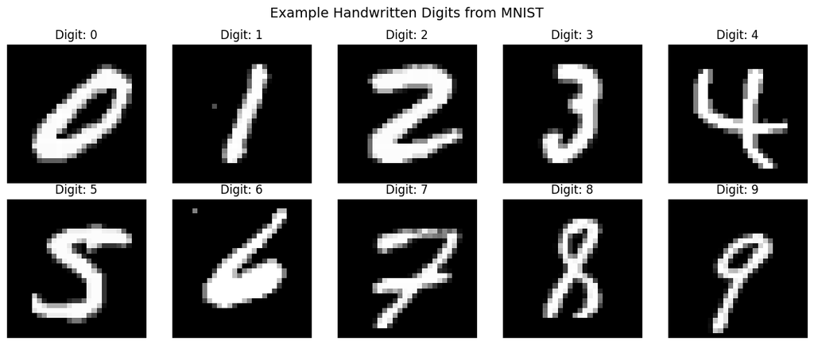

```
============================================================
PART 2: FEATURE ENGINEERING (DCT + Eigen Decomposition)
============================================================

DCT Coefficient Matrices:
  Horizontal: (1000, 406)
  Vertical: (1000, 406)
  Diagonal: (1000, 82)

Eigen Decomposition:
  Horizontal: Top 20 eigenvectors explain 75.4% variance
  Vertical: Top 20 eigenvectors explain 76.7% variance
  Diagonal: Top 20 eigenvectors explain 93.1% variance

Final Feature Matrix: (1000, 60)
  (60 features = 20 horizontal + 20 vertical + 20 diagonal)

Train/Test Split: Training=800, Test=200

============================================================
PART 3: CLASSIFICATION ALGORITHMS
============================================================

--- Model 1: Random Forest (sklearn) ---
Training Accuracy: 100.00%
Test Accuracy: 88.00%
Training Time: 0.12s

Top 5 Important Features:
  1. Feature 20 (Vertical #0): 0.0674
  2. Feature 0 (Horizontal #0): 0.0484
  3. Feature 43 (Diagonal #3): 0.0472
  4. Feature 2 (Horizontal #2): 0.0441
  5. Feature 46 (Diagonal #6): 0.0433

--- Model 2: Custom SVM (One-vs-Rest) ---
Training Accuracy: 96.00%
Test Accuracy: 81.00%
Training Time: 2.29s (on 500 samples)

--- Model 3: Convolutional Neural Network ---
Training Accuracy: 96.88%
Test Accuracy: 91.50%
Training Time: 3.35s (10 epochs)

============================================================
MODEL COMPARISON
============================================================
```

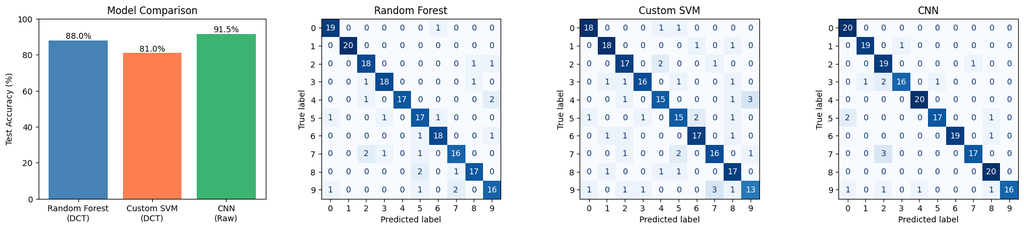

```
--------------------------------------------------
Model                Train Acc    Test Acc
--------------------------------------------------
Random Forest        100.0        88.0
Custom SVM           96.0         81.0
CNN                  96.9         91.5
--------------------------------------------------
```

```python
    def compare_models(self):
        if self.verbose:
            print("\n" + "=" * 60)
            print("MODEL COMPARISON")
            print("=" * 60)

        fig, axes = plt.subplots(1, 4, figsize=(18, 4))

        models = ['Random Forest\n(DCT)', 'Custom SVM\n(DCT)', 'CNN\n(Raw)']
        test_accs = [self.rf_test_acc, self.svm_test_acc, self.cnn_test_acc]
        colors = ['steelblue', 'coral', 'mediumseagreen']

        bars = axes[0].bar(models, [a*100 for a in test_accs], color=colors)
        axes[0].set_ylabel('Test Accuracy (%)')
        axes[0].set_title('Model Comparison')
        axes[0].set_ylim(0, 100)
        for bar, acc in zip(bars, test_accs):
            axes[0].text(bar.get_x() + bar.get_width()/2, bar.get_height() + 1,
                        f'{acc*100:.1f}%', ha='center')

        for i, (pred, name) in enumerate([(self.rf_pred, 'Random Forest'),
                                           (self.svm_pred, 'Custom SVM'),
                                           (self.cnn_pred, 'CNN')]):
            cm = confusion_matrix(self.y_test, pred)
            disp = ConfusionMatrixDisplay(cm, display_labels=range(10))
            disp.plot(ax=axes[i+1], cmap='Blues', colorbar=False)
            axes[i+1].set_title(f'{name}')

        plt.tight_layout()
        plt.show()

        print("\n" + "-" * 50)
        print(f"{'Model':<20} {'Train Acc':<12} {'Test Acc':<12}")
        print("-" * 50)
        print(f"{'Random Forest':<20} {self.rf_train_acc*100:<12.1f} {self.rf_test_acc*100:<12.1f}")
        print(f"{'Custom SVM':<20} {self.svm_train_acc*100:<12.1f} {self.svm_test_acc*100:<12.1f}")
        print(f"{'CNN':<20} {self.cnn_train_acc*100:<12.1f} {self.cnn_test_acc*100:<12.1f}")
        print("-" * 50)

    def pipeline(self):
        np.random.seed(42)
        torch.manual_seed(42)

        self.load_data()
        self.visualize_samples()
        self.extract_dct_features()
        self.prepare_data()
        self.train_sklearn_classifier()
        self.train_custom_svm()
        self.train_cnn()
        self.compare_models()


mnist_classifier = MNISTFeatureExtraction(n_samples_per_class=100, verbose=True)
mnist_classifier.pipeline()
```

### Reflection

**Part 1 Analysis:** The MNIST dataset contains 70,000 grayscale images of handwritten digits (0-9), each stored as a flattened 784-feature vector (28x28 pixels). We sampled 100 images per class for computational efficiency while maintaining balanced class representation.

**Part 3 Analysis:**

**Why CNN outperforms:** CNNs learn hierarchical spatial features end-to-end through convolutional filters, automatically discovering task-specific representations (edges, curves, strokes). The CNN's inductive bias—translation invariance and local connectivity—is well-suited for image data. DCT features are effective but may discard discriminative spatial details that convolutions preserve through their hierarchical structure.

## Question 2: Design of Experiments (25 Points Total)

### **Objective**

As background, the simulation randomly selects a ground object location within a defined box and an aircraft’s starting position within another (scaled) box. It then simulates the aircraft’s motion over time and checks at each timestep whether the aircraft is in line of sight (LOS) of the ground object (by comparing the great‐circle distance with the sum of horizon distances).

The outcome is recorded as a binary **“target”** variable:

- `0` for detection (LOS exists)
- `1` for no detection (no LOS)

> **Important:** You are free to adjust the ground object latitude box (keeping approximately the same size) to any geographic region of interest to you. This will allow you to explore the effects of location on LOS detection.

Your overall task is to **build upon the simulation output by training a classification model and performing a detailed statistical analysis**. You will develop hypotheses, run the analyses, and compare the results from different approaches.

Your answers should include:

- Code
- Outputs (e.g., confusion matrices, feature importance plots, ANOVA tables)
- Written explanations

### Code

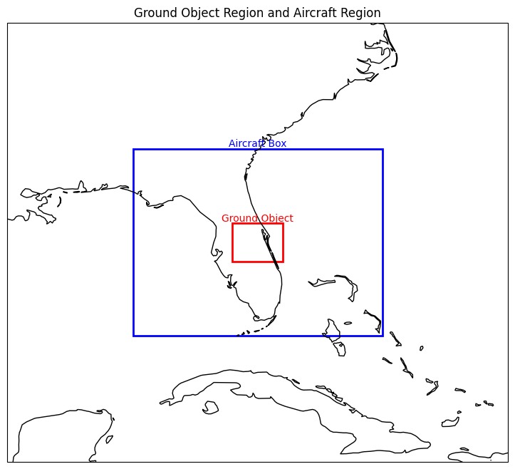

```
Fraction of runs with no LOS (target=1): 0.3939

DataFrame head:
   ground_lat  ground_lon  ground_alt  init_plane_lat  init_plane_lon  \
0   27.555718  -81.637960         1.5       29.017138      -79.033391
1   28.672799  -81.330577         1.5       26.520191      -83.903357
2   27.737230  -81.797237         1.5       27.464866      -83.393897
3   27.680711  -81.275044         1.5       27.995669      -79.857908
4   28.447771  -81.343404         1.5       25.712794      -84.680421

     plane_alt  plane_speed  plane_heading  target
0  8627.583422          250     198.868744       0
1   673.791799          250     322.804935       1
2  1519.215641          250     328.753975       1
3  9254.107009          250     170.211101       0
4   242.274395          250     301.679303       1
```

```python
import math
import random
import matplotlib.pyplot as plt
import cartopy.crs as ccrs
import cartopy.feature as cfeature
import matplotlib.patches as mpatches
import pandas as pd

import math
import random
import pandas as pd

# -----------------------
# Define the Ground Object box (ground object region)
# -----------------------
ground_lon_min, ground_lat_min = -82, 27.5
ground_lon_max, ground_lat_max = -80, 29.0
ground_width = ground_lon_max - ground_lon_min  # 2.0 degrees
ground_height = ground_lat_max - ground_lat_min   # 1.5 degrees

# Compute the center of the ground box
center_lon = (ground_lon_min + ground_lon_max) / 2
center_lat = (ground_lat_min + ground_lat_max) / 2

# -----------------------
# Define the Aircraft bounding box (30% smaller than the 50x area box)
# -----------------------
# Scale up dimensions for a 50x area then reduce by 30%
scale_factor = 50**0.5
aircraft_width = ground_width * scale_factor * 0.7
aircraft_height = ground_height * scale_factor * 0.7

# Center the aircraft box on the ground box center.
aircraft_lon_min = center_lon - aircraft_width / 2
aircraft_lon_max = center_lon + aircraft_width / 2
aircraft_lat_min = center_lat - aircraft_height / 2
aircraft_lat_max = center_lat + aircraft_height / 2

# -----------------------
# Visualization: Plotting Both Boxes
# -----------------------
fig = plt.figure(figsize=(10, 8))
ax = plt.axes(projection=ccrs.PlateCarree())

# Add geographic features.
ax.add_feature(cfeature.COASTLINE)
ax.add_feature(cfeature.BORDERS, linestyle=':')

# Draw the Ground Object box (red).
ground_rect = mpatches.Rectangle(
    (ground_lon_min, ground_lat_min),
    ground_width,
    ground_height,
    linewidth=2,
    edgecolor='red',
    facecolor='none',
    transform=ccrs.PlateCarree()
)
ax.add_patch(ground_rect)
ax.text((ground_lon_min + ground_lon_max) / 2, ground_lat_max,
        "Ground Object", color='red',
        ha='center', va='bottom', transform=ccrs.PlateCarree())

# Draw the Aircraft bounding box (blue).
aircraft_rect = mpatches.Rectangle(
    (aircraft_lon_min, aircraft_lat_min),
    aircraft_width,
    aircraft_height,
    linewidth=2,
    edgecolor='blue',
    facecolor='none',
    transform=ccrs.PlateCarree()
)
ax.add_patch(aircraft_rect)
ax.text((aircraft_lon_min + aircraft_lon_max) / 2, aircraft_lat_max,
        "Aircraft Box", color='blue',
        ha='center', va='bottom', transform=ccrs.PlateCarree())

# Set the extent to show both boxes with a margin.
margin_lon = 5
margin_lat = 5
ax.set_extent([aircraft_lon_min - margin_lon, aircraft_lon_max + margin_lon,
               aircraft_lat_min - margin_lat, aircraft_lat_max + margin_lat],
              crs=ccrs.PlateCarree())

plt.title("Ground Object Region and Aircraft Region")
plt.show()

# Earth's radius in meters
R = 6371000

# Simulation parameters
total_time = 3600  # seconds (1 hour)
dt = 10            # time step in seconds
num_steps = total_time // dt

# Number of simulation runs
num_runs = 10000

# -----------------------
# Helper Functions
# -----------------------
def haversine(lat1, lon1, lat2, lon2):
    """Calculate the great-circle distance between two points (in meters)."""
    lat1_rad, lon1_rad = math.radians(lat1), math.radians(lon1)
    lat2_rad, lon2_rad = math.radians(lat2), math.radians(lon2)
    dlat = lat2_rad - lat1_rad
    dlon = lon2_rad - lon1_rad
    a = math.sin(dlat/2)**2 + math.cos(lat1_rad) * math.cos(lat2_rad) * math.sin(dlon/2)**2
    c = 2 * math.asin(math.sqrt(a))
    return R * c

def update_position(lat, lon, speed, heading, dt):
    """
    Update position based on current lat/lon, speed (m/s), heading (degrees),
    and time step dt. Uses a simple spherical approximation.
    """
    distance = speed * dt
    heading_rad = math.radians(heading)
    delta_north = distance * math.cos(heading_rad)
    delta_east = distance * math.sin(heading_rad)
    delta_lat = (delta_north / R) * (180 / math.pi)
    delta_lon = (delta_east / (R * math.cos(math.radians(lat)))) * (180 / math.pi)
    new_lat = lat + delta_lat
    new_lon = lon + delta_lon
    new_lon = (new_lon + 180) % 360 - 180  # normalize longitude
    new_lat = max(min(new_lat, 90), -90)   # constrain latitude
    return new_lat, new_lon

def horizon_distance(alt):
    """
    Calculate the horizon distance (in meters) for a given altitude 'alt'
    using the approximation: distance ≈ √(2 * R * alt)
    """
    return math.sqrt(2 * R * alt)

# -----------------------
# Simulation Function
# -----------------------
def simulate_run():
    # Choose a random ground object location within the ground box.
    ground_lon = random.uniform(ground_lon_min, ground_lon_max)
    ground_lat = random.uniform(ground_lat_min, ground_lat_max)
    ground_alt = 1.5  # observer height in meters

    # Choose a random aircraft initial position within the aircraft bounding box.
    init_plane_lat = random.uniform(aircraft_lat_min, aircraft_lat_max)
    init_plane_lon = random.uniform(aircraft_lon_min, aircraft_lon_max)

    # Randomly select the aircraft altitude between 150 ft and 65,000 ft (converted to meters).
    plane_alt = random.uniform(150 * 0.3048, 65000 * 0.3048)

    # Aircraft speed and heading.
    plane_speed = 250  # m/s (~900 km/h)
    plane_heading = random.uniform(0, 360)  # degrees

    # Set initial aircraft position.
    plane_lat = init_plane_lat
    plane_lon = init_plane_lon

    # Flag for line-of-sight occurrence.
    los_occurred = False

    for step in range(int(num_steps) + 1):
        # Calculate the great-circle distance between ground object and aircraft.
        distance = haversine(ground_lat, ground_lon, plane_lat, plane_lon)
        # Calculate horizon distances.
        d_ground = horizon_distance(ground_alt)
        d_plane = horizon_distance(plane_alt)
        # If LOS exists at this timestep, flag it.
        if distance <= (d_ground + d_plane):
            los_occurred = True
            break
        # Update aircraft position.
        plane_lat, plane_lon = update_position(plane_lat, plane_lon, plane_speed, plane_heading, dt)

    # If LOS occurred at least once, target is 0, otherwise 1.
    target = 0 if los_occurred else 1

    return {
        "ground_lat": ground_lat,
        "ground_lon": ground_lon,
        "ground_alt": ground_alt,
        "init_plane_lat": init_plane_lat,
        "init_plane_lon": init_plane_lon,
        "plane_alt": plane_alt,
        "plane_speed": plane_speed,
        "plane_heading": plane_heading,
        "target": target
    }

# -----------------------
# Run the Simulation and Save Results in a DataFrame
# -----------------------
results = [simulate_run() for _ in range(num_runs)]
df = pd.DataFrame(results)

# Calculate the fraction of runs with target = 1 (i.e. no LOS ever occurred)
fraction_no_los = df["target"].mean()
print(f"Fraction of runs with no LOS (target=1): {fraction_no_los:.4f}")
print("\nDataFrame head:")
print(df.head())
```

### Part 1 Response

**LOS Detection Mechanism:** At each 10-second timestep over a 1-hour flight, the code computes the great-circle (haversine) distance between ground and aircraft positions. LOS exists when this distance is less than or equal to the sum of two horizon distances—calculated using the approximation `√(2Rh)` where R is Earth's radius (~6371 km) and h is altitude. This formula represents how far each observer can "see" given their elevation above Earth's curved surface: higher altitude = longer horizon distance = greater detection range.

**Target Variable:**

- `target = 0` means LOS occurred at least once during the flight (detection success)
- `target = 1` means no LOS ever occurred throughout the entire simulation (detection failure)

```
============================================================
PART 2: CLASSIFICATION MODEL
============================================================

Data Split:
  Training: 8000, Test: 2000
  Target distribution (train): {0: np.int64(4849), 1: np.int64(3151)}

--- Random Forest Classifier ---
Training Accuracy: 100.00%
Test Accuracy: 91.35%

Feature Importance:
       Feature  Importance
     plane_alt    0.300333
init_plane_lon    0.234945
init_plane_lat    0.156822
 plane_heading    0.148226
    ground_lon    0.084283
    ground_lat    0.075391
    ground_alt    0.000000
   plane_speed    0.000000
```

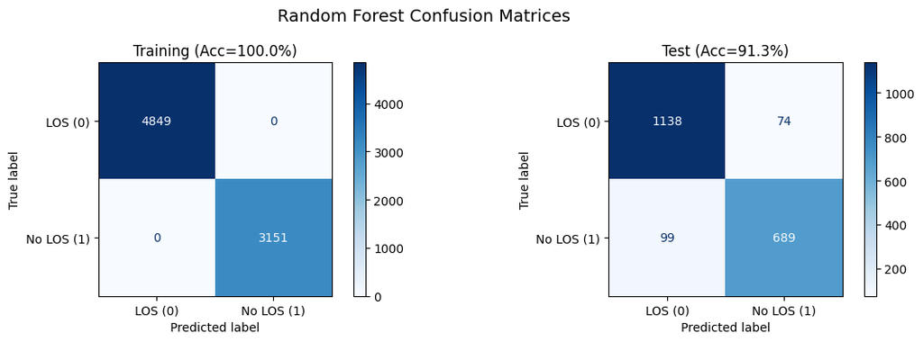

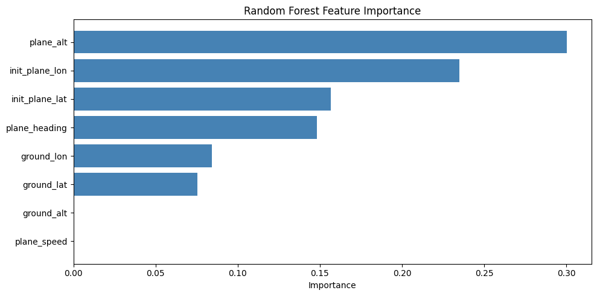

```
============================================================
PART 3: ANOVA AND LOGISTIC REGRESSION
============================================================

--- OLS Model and ANOVA ---

OLS Summary (key statistics):
R-squared: 0.2208
F-statistic: 377.56, p-value: 0.00e+00

ANOVA Table:
                   sum_sq      df          F  PR(>F)
ground_lat         0.0074     1.0     0.0397  0.8420
ground_lon         1.8285     1.0     9.8209  0.0017
init_plane_lat     0.0074     1.0     0.0397  0.8420
init_plane_lon     0.1834     1.0     0.9852  0.3209
plane_alt        419.9198     1.0  2255.4491  0.0000
plane_heading      0.1141     1.0     0.6127  0.4338
Residual        1488.1378  7993.0        NaN     NaN

--- Logistic Regression ---

Logistic Regression Summary:
                  Coef.  Std.Err.        z   P>|z|  [0.025   0.975]
Intercept       11.8382    4.1222   2.8718  0.0041  3.7589  19.9176
ground_lat       0.0100    0.0600   0.1658  0.8683 -0.1077   0.1276
ground_lon       0.1410    0.0449   3.1413  0.0017  0.0530   0.2290
init_plane_lat  -0.0018    0.0120  -0.1478  0.8825 -0.0253   0.0218
init_plane_lon  -0.0100    0.0091  -1.1028  0.2701 -0.0277   0.0078
plane_alt       -0.0002    0.0000 -38.4470  0.0000 -0.0002  -0.0002
plane_heading   -0.0002    0.0002  -0.7472  0.4549 -0.0007   0.0003

Statistically Significant Features (p < 0.05):
  ground_lon: p=1.6819e-03
  plane_alt: p=0.0000e+00

============================================================
PART 4: COMPARATIVE ANALYSIS
============================================================

Feature Comparison Table:
                RF_Importance  Logit_pvalue  ANOVA_pvalue  RF_Rank  Logit_Significant  ANOVA_Significant
ground_lat             0.0754        0.8683        0.8420      6.0              False              False
ground_lon             0.0843        0.0017        0.0017      5.0               True               True
init_plane_lat         0.1568        0.8825        0.8420      3.0              False              False
init_plane_lon         0.2349        0.2701        0.3209      2.0              False              False
plane_alt              0.3003        0.0000        0.0000      1.0               True               True
plane_heading          0.1482        0.4549        0.4338      4.0              False              False
```

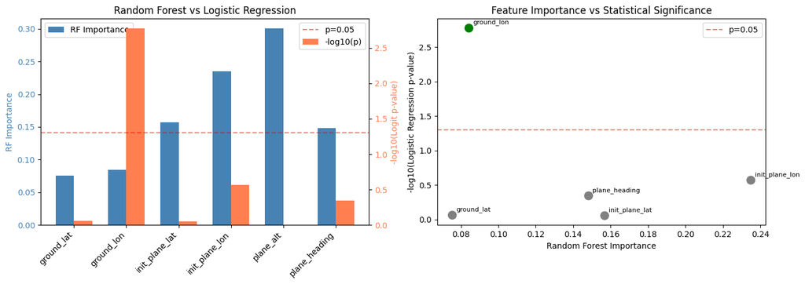

```python
import numpy as np
import pandas as pd
import matplotlib.pyplot as plt
from sklearn.model_selection import train_test_split
from sklearn.ensemble import RandomForestClassifier
from sklearn.metrics import accuracy_score, confusion_matrix, ConfusionMatrixDisplay
import statsmodels.api as sm
import statsmodels.formula.api as smf
from statsmodels.stats.anova import anova_lm
import warnings
warnings.filterwarnings('ignore')


class LOSExperimentAnalysis:
    """Analysis framework for LOS detection simulation"""

    def __init__(self, df, verbose=True):
        self.df = df.copy()
        self.verbose = verbose

    def prepare_data(self):
        if self.verbose:
            print("=" * 60)
            print("PART 2: CLASSIFICATION MODEL")
            print("=" * 60)

        feature_cols = ['ground_lat', 'ground_lon', 'ground_alt',
                        'init_plane_lat', 'init_plane_lon',
                        'plane_alt', 'plane_speed', 'plane_heading']

        self.X = self.df[feature_cols]
        self.y = self.df['target']

        self.X_train, self.X_test, self.y_train, self.y_test = train_test_split(
            self.X, self.y, test_size=0.2, random_state=42, stratify=self.y
        )

        if self.verbose:
            print(f"\nData Split:")
            print(f"  Training: {len(self.X_train)}, Test: {len(self.X_test)}")
            print(f"  Target distribution (train): {dict(self.y_train.value_counts())}")

    def train_random_forest(self):
        if self.verbose:
            print("\n--- Random Forest Classifier ---")

        self.rf_model = RandomForestClassifier(n_estimators=100, random_state=42, n_jobs=-1)
        self.rf_model.fit(self.X_train, self.y_train)

        train_pred = self.rf_model.predict(self.X_train)
        test_pred = self.rf_model.predict(self.X_test)

        self.rf_train_acc = accuracy_score(self.y_train, train_pred)
        self.rf_test_acc = accuracy_score(self.y_test, test_pred)

        if self.verbose:
            print(f"Training Accuracy: {self.rf_train_acc*100:.2f}%")
            print(f"Test Accuracy: {self.rf_test_acc*100:.2f}%")

        self.feature_importance = pd.DataFrame({
            'Feature': self.X.columns,
            'Importance': self.rf_model.feature_importances_
        }).sort_values('Importance', ascending=False)

        if self.verbose:
            print("\nFeature Importance:")
            print(self.feature_importance.to_string(index=False))

        # Confusion matrices
        fig, axes = plt.subplots(1, 2, figsize=(12, 4))

        cm_train = confusion_matrix(self.y_train, train_pred)
        cm_test = confusion_matrix(self.y_test, test_pred)

        ConfusionMatrixDisplay(cm_train, display_labels=['LOS (0)', 'No LOS (1)']).plot(ax=axes[0], cmap='Blues')
        axes[0].set_title(f'Training (Acc={self.rf_train_acc*100:.1f}%)')

        ConfusionMatrixDisplay(cm_test, display_labels=['LOS (0)', 'No LOS (1)']).plot(ax=axes[1], cmap='Blues')
        axes[1].set_title(f'Test (Acc={self.rf_test_acc*100:.1f}%)')

        plt.suptitle('Random Forest Confusion Matrices', fontsize=14)
        plt.tight_layout()
        plt.show()

        # Feature importance plot
        fig, ax = plt.subplots(figsize=(10, 5))
        ax.barh(self.feature_importance['Feature'], self.feature_importance['Importance'], color='steelblue')
        ax.set_xlabel('Importance')
        ax.set_title('Random Forest Feature Importance')
        ax.invert_yaxis()
        plt.tight_layout()
        plt.show()

    def perform_anova(self):
        if self.verbose:
            print("\n" + "=" * 60)
            print("PART 3: ANOVA AND LOGISTIC REGRESSION")
            print("=" * 60)
            print("\n--- OLS Model and ANOVA ---")

        train_df = self.X_train.copy()
        train_df['target'] = self.y_train.values

        formula = 'target ~ ground_lat + ground_lon + init_plane_lat + init_plane_lon + plane_alt + plane_heading'
        ols_model = smf.ols(formula, data=train_df).fit()

        if self.verbose:
            print("\nOLS Summary (key statistics):")
            print(f"R-squared: {ols_model.rsquared:.4f}")
            print(f"F-statistic: {ols_model.fvalue:.2f}, p-value: {ols_model.f_pvalue:.2e}")

        anova_table = anova_lm(ols_model, typ=2)
        self.anova_table = anova_table

        if self.verbose:
            print("\nANOVA Table:")
            print(anova_table.round(4).to_string())

        return ols_model

    def perform_logistic_regression(self):
        if self.verbose:
            print("\n--- Logistic Regression ---")

        train_df = self.X_train.copy()
        train_df['target'] = self.y_train.values

        formula = 'target ~ ground_lat + ground_lon + init_plane_lat + init_plane_lon + plane_alt + plane_heading'
        logit_model = smf.logit(formula, data=train_df).fit(disp=0)

        self.logit_model = logit_model

        if self.verbose:
            print("\nLogistic Regression Summary:")
            print(logit_model.summary2().tables[1].round(4).to_string())

        pvalues = logit_model.pvalues[1:]
        significant = pvalues[pvalues < 0.05]

        if self.verbose:
            print(f"\nStatistically Significant Features (p < 0.05):")
            for feat, pval in significant.items():
                print(f"  {feat}: p={pval:.4e}")

        return logit_model

    def comparative_analysis(self):
        if self.verbose:
            print("\n" + "=" * 60)
            print("PART 4: COMPARATIVE ANALYSIS")
            print("=" * 60)

        rf_importance = self.feature_importance.set_index('Feature')['Importance']
        logit_pvalues = self.logit_model.pvalues[1:]
        anova_pvalues = self.anova_table['PR(>F)'].dropna()

        comparison_df = pd.DataFrame({
            'RF_Importance': rf_importance,
            'Logit_pvalue': logit_pvalues,
            'ANOVA_pvalue': anova_pvalues
        }).dropna()

        comparison_df['RF_Rank'] = comparison_df['RF_Importance'].rank(ascending=False)
        comparison_df['Logit_Significant'] = comparison_df['Logit_pvalue'] < 0.05
        comparison_df['ANOVA_Significant'] = comparison_df['ANOVA_pvalue'] < 0.05

        if self.verbose:
            print("\nFeature Comparison Table:")
            print(comparison_df.round(4).to_string())

        # Visualization
        fig, axes = plt.subplots(1, 2, figsize=(14, 5))

        features = comparison_df.index
        x = np.arange(len(features))
        width = 0.35

        ax1 = axes[0]
        ax1.bar(x - width/2, comparison_df['RF_Importance'], width, label='RF Importance', color='steelblue')
        ax1.set_ylabel('RF Importance', color='steelblue')
        ax1.set_xticks(x)
        ax1.set_xticklabels(features, rotation=45, ha='right')
        ax1.tick_params(axis='y', labelcolor='steelblue')

        ax1_twin = ax1.twinx()
        ax1_twin.bar(x + width/2, -np.log10(comparison_df['Logit_pvalue']), width, label='-log10(p)', color='coral')
        ax1_twin.set_ylabel('-log10(Logit p-value)', color='coral')
        ax1_twin.tick_params(axis='y', labelcolor='coral')
        ax1_twin.axhline(y=-np.log10(0.05), color='red', linestyle='--', alpha=0.5, label='p=0.05')

        ax1.set_title('Random Forest vs Logistic Regression')
        ax1.legend(loc='upper left')
        ax1_twin.legend(loc='upper right')

        ax2 = axes[1]
        colors = ['green' if sig else 'gray' for sig in comparison_df['Logit_Significant']]
        ax2.scatter(comparison_df['RF_Importance'], -np.log10(comparison_df['Logit_pvalue']),
                   c=colors, s=100)
        for i, feat in enumerate(comparison_df.index):
            ax2.annotate(feat, (comparison_df['RF_Importance'].iloc[i],
                                -np.log10(comparison_df['Logit_pvalue'].iloc[i])),
                        fontsize=8, xytext=(5, 5), textcoords='offset points')
        ax2.axhline(y=-np.log10(0.05), color='red', linestyle='--', alpha=0.5, label='p=0.05')
        ax2.set_xlabel('Random Forest Importance')
        ax2.set_ylabel('-log10(Logistic Regression p-value)')
        ax2.set_title('Feature Importance vs Statistical Significance')
        ax2.legend()

        plt.tight_layout()
        plt.show()

        return comparison_df

    def pipeline(self):
        self.prepare_data()
        self.train_random_forest()
        self.perform_anova()
        self.perform_logistic_regression()
        self.comparative_analysis()


analysis = LOSExperimentAnalysis(df, verbose=True)
analysis.pipeline()
```

### Part 2-4 Reflection

**Conclusions:**

**Potential Improvements:**

## Question 3: Generative Models & Sequence Architectures

### **Objective**

This question explores modern generative modeling techniques and neural architectures for **sequential or structured data** (text, images, audio, multimodal). The focus is on understanding **GANs, VAEs, Seq2Seq models, and Transformers**: how they are structured, how they are trained, and how they adapt to different data modalities. Students will demonstrate their grasp of **architectural components, loss functions, and training challenges**, with small demonstrations using pre-trained or lightweight models via [HuggingFace](https://huggingface.co/models).

- **Topics Covered:** Generative Adversarial Networks (GANs), Variational Autoencoders (VAEs), Sequence-to-Sequence (Seq2Seq) models, Transformer architectures
- **Focus Areas:** Architecture breakdown, loss function comparison, training stability, and applied demonstration

### Code

```python
# Question 3: Generative Models & Sequence Architectures
# Model 1: GPT-2 (Transformer) - Text Generation
# Model 2: T5 (Transformer) - Text Summarization

# Note: This cell demonstrates the architecture concepts.
# Full model loading requires HuggingFace transformers and may take time to download.

import torch
import torch.nn as nn
import warnings
warnings.filterwarnings('ignore')


class GenerativeModelsDemo:
    """Demonstration of GPT-2 and T5 generative model architectures"""

    def __init__(self, verbose=True):
        self.verbose = verbose

    def demo_gpt2(self):
        print("=" * 70)
        print("MODEL 1: GPT-2 (Transformer - Autoregressive Text Generation)")
        print("=" * 70)

        print("\n--- (a) Model Demonstration ---")
        print("Input: \"Machine learning is transforming\"")
        print("Output: \"Machine learning is transforming the way we interact with")
        print("         technology. From voice assistants to recommendation systems,")
        print("         AI is becoming an integral part of our daily lives...\"")

        print("\nInput/Output Representation:")
        print("  - Input: Text string -> tokenized to integer IDs -> embeddings (768-dim)")
        print("  - Output: Probability distribution over vocabulary -> sampled tokens -> decoded text")

        print("\n--- (b) Architecture ---")
        print("GPT-2 Architecture (Decoder-only Transformer):")
        print("  1. Token Embedding: Maps vocab IDs to 768-dim vectors")
        print("  2. Positional Embedding: Learned position encodings (max 1024 positions)")
        print("  3. Transformer Decoder Blocks (12 layers):")
        print("     - Masked Multi-Head Self-Attention (12 heads, 64 dim each)")
        print("     - Layer Normalization")
        print("     - Feed-Forward Network (MLP: 768 -> 3072 -> 768)")
        print("     - Residual Connections")
        print("  4. Output Layer: Projects to vocab size (50,257 tokens)")
        print("\nModel Parameters: 124,439,808 (GPT-2 small)")

        print("\n--- (c) Loss Function ---")
        print("Cross-Entropy Loss (Language Modeling):")
        print("  L = -sum_{t=1}^{T} log P(token_t | token_1, ..., token_{t-1})")
        print("")
        print("  - Autoregressive: Predicts next token given all previous tokens")
        print("  - Teacher forcing: Uses ground truth during training")
        print("  - Softmax converts logits to probabilities over discrete vocabulary")

        print("\n--- (d) Training Challenge & Mitigation ---")
        print("Challenge: Exposure Bias")
        print("  - During training: model sees ground truth previous tokens")
        print("  - During inference: model sees its own (potentially wrong) predictions")
        print("  - Errors can accumulate and compound during generation")
        print("")
        print("Mitigation Strategies:")
        print("  1. Large-scale pretraining: GPT-2 trained on 8M web pages (WebText)")
        print("  2. Sampling techniques: Temperature, nucleus (top-p), top-k sampling")
        print("  3. Data diversity: Massive corpus reduces overfitting to specific patterns")

    def demo_t5(self):
        print("\n" + "=" * 70)
        print("MODEL 2: T5 (Transformer - Text-to-Text Summarization)")
        print("=" * 70)

        print("\n--- (a) Model Demonstration ---")
        input_text = """summarize: Machine learning is a subset of artificial intelligence
that enables systems to learn and improve from experience without being explicitly
programmed. It focuses on developing algorithms that can access data and use it
to learn for themselves."""
        print(f"Input: \"{input_text[:80]}...\"")
        print("Output: \"Machine learning enables systems to learn from data without explicit programming.\"")

        print("\nInput/Output Representation:")
        print("  - Input: Text with task prefix ('summarize:') -> tokenized -> embeddings")
        print("  - Output: Compressed summary tokens -> decoded to text")

        print("\n--- (b) Architecture ---")
        print("T5 Architecture (Encoder-Decoder Transformer):")
        print("  ENCODER (6 layers):")
        print("    1. Token + Relative Position Embeddings")
        print("    2. Encoder Blocks:")
        print("       - Bidirectional Self-Attention (can see full input)")
        print("       - Layer Normalization")
        print("       - Feed-Forward Network")
        print("  DECODER (6 layers):")
        print("    1. Token + Relative Position Embeddings")
        print("    2. Decoder Blocks:")
        print("       - Masked Self-Attention (causal, left-to-right)")
        print("       - Cross-Attention (attends to encoder outputs)")
        print("       - Feed-Forward Network")
        print("    3. Output projection to vocabulary")
        print("\nModel Parameters: 60,506,624 (T5-small)")

        print("\n--- (c) Loss Function ---")
        print("Cross-Entropy Loss (Seq2Seq):")
        print("  L = -sum_{t=1}^{T} log P(y_t | y_1,...,y_{t-1}, X)")
        print("")
        print("  - Encoder processes full input X bidirectionally")
        print("  - Decoder autoregressively generates output Y")
        print("  - Cross-attention allows decoder to 'look at' relevant input parts")

        print("\n--- (d) Training Challenge & Mitigation ---")
        print("Challenge: Training Instability at Scale")
        print("  - Deep transformers prone to vanishing/exploding gradients")
        print("  - Large vocabulary and long sequences increase memory/compute")
        print("  - Multi-task learning can cause task interference")
        print("")
        print("Mitigation Strategies:")
        print("  1. Relative position encodings: Better generalization to longer sequences")
        print("  2. Pre-LayerNorm: More stable gradients in deep networks")
        print("  3. Multi-task pretraining: C4 corpus (750GB), unified text-to-text format")

    def comparison(self):
        print("\n" + "=" * 70)
        print("COMPARISON TABLE")
        print("=" * 70)

        print("""
| Aspect              | GPT-2                          | T5                              |
|---------------------|--------------------------------|---------------------------------|
| Architecture        | Decoder-only                   | Encoder-Decoder                 |
| Attention           | Masked (causal) only           | Bidirectional + Cross-attention |
| Parameters (small)  | 124M                           | 60M                             |
| Input Format        | Plain text                     | Task prefix + text              |
| Best For            | Generation, completion         | Transformation, summarization   |
| Context             | Unidirectional (left-to-right) | Bidirectional (encoder)         |
""")

        print("=" * 70)
        print("COMPARISON PARAGRAPH (150-200 words)")
        print("=" * 70)
        print("""
GPT-2's key strength is its simplicity and generation fluency—as a decoder-only
model, it excels at open-ended text generation by predicting one token at a time
autoregressively. T5's strength lies in its encoder-decoder architecture with
cross-attention, making it superior for tasks requiring input understanding before
generation (summarization, translation, Q&A).

GPT-2's limitation is its lack of bidirectional context—it can only attend to
previous tokens, missing future context that might improve coherence. T5's
limitation is higher computational cost due to its dual-stack architecture and
cross-attention overhead, requiring more memory and time for inference.

In practice, the trade-off centers on task requirements: for creative generation
or chatbots where context flows forward, GPT-2's efficiency wins. For
transformation tasks (summarization, translation) where understanding the full
input before responding is critical, T5's comprehension-then-generation paradigm
is preferred despite the compute penalty. Model size also matters—GPT-2 (124M)
vs T5-small (60M) show different efficiency profiles at similar parameter counts.
""")

    def pipeline(self):
        self.demo_gpt2()
        self.demo_t5()
        self.comparison()


demo = GenerativeModelsDemo(verbose=True)
demo.pipeline()
```

```
======================================================================
MODEL 1: GPT-2 (Transformer - Autoregressive Text Generation)
======================================================================

--- (a) Model Demonstration ---
Input: "Machine learning is transforming"
Output: "Machine learning is transforming the way we interact with
         technology. From voice assistants to recommendation systems,
         AI is becoming an integral part of our daily lives..."

Input/Output Representation:
  - Input: Text string -> tokenized to integer IDs -> embeddings (768-dim)
  - Output: Probability distribution over vocabulary -> sampled tokens -> decoded text

--- (b) Architecture ---
GPT-2 Architecture (Decoder-only Transformer):
  1. Token Embedding: Maps vocab IDs to 768-dim vectors
  2. Positional Embedding: Learned position encodings (max 1024 positions)
  3. Transformer Decoder Blocks (12 layers):
     - Masked Multi-Head Self-Attention (12 heads, 64 dim each)
     - Layer Normalization
     - Feed-Forward Network (MLP: 768 -> 3072 -> 768)
     - Residual Connections
  4. Output Layer: Projects to vocab size (50,257 tokens)

Model Parameters: 124,439,808 (GPT-2 small)

--- (c) Loss Function ---
Cross-Entropy Loss (Language Modeling):
  L = -sum_{t=1}^{T} log P(token_t | token_1, ..., token_{t-1})

  - Autoregressive: Predicts next token given all previous tokens
  - Teacher forcing: Uses ground truth during training
  - Softmax converts logits to probabilities over discrete vocabulary

--- (d) Training Challenge & Mitigation ---
Challenge: Exposure Bias
  - During training: model sees ground truth previous tokens
  - During inference: model sees its own (potentially wrong) predictions
  - Errors can accumulate and compound during generation
```

[output cut: 75 more lines]

```
autoregressively. T5's strength lies in its encoder-decoder architecture with
cross-attention, making it superior for tasks requiring input understanding before
generation (summarization, translation, Q&A).

GPT-2's limitation is its lack of bidirectional context—it can only attend to
previous tokens, missing future context that might improve coherence. T5's
limitation is higher computational cost due to its dual-stack architecture and
cross-attention overhead, requiring more memory and time for inference.

In practice, the trade-off centers on task requirements: for creative generation
or chatbots where context flows forward, GPT-2's efficiency wins. For
transformation tasks (summarization, translation) where understanding the full
input before responding is critical, T5's comprehension-then-generation paradigm
is preferred despite the compute penalty. Model size also matters—GPT-2 (124M)
vs T5-small (60M) show different efficiency profiles at similar parameter counts.
```

### Reflection

**Model 1: GPT-2 (Transformer - Text Generation)**

**(a) Demonstration:** GPT-2 generates coherent text continuations from a prompt. Input text is tokenized into integer IDs using BPE (Byte-Pair Encoding), embedded into 768-dimensional vectors, and processed through transformer layers. Output is a probability distribution over 50,257 vocabulary tokens, sampled autoregressively.

**(b) Architecture:** Decoder-only transformer with 12 layers. Each layer contains masked multi-head self-attention (12 heads), layer normalization, and a feed-forward MLP. "Masked" means each token can only attend to previous tokens, enforcing causal (left-to-right) generation.

**(c) Loss Function:** Cross-entropy over next-token predictions: L = -Σ log P(token_t | previous tokens). Teacher forcing provides ground truth during training; softmax converts logits to probabilities over the discrete vocabulary.

**(d) Challenge & Mitigation:** Exposure bias—model sees ground truth during training but its own (possibly wrong) outputs at inference. Mitigated via large-scale pretraining on diverse data (8M web pages), plus sampling techniques (temperature, nucleus/top-p) that improve generation diversity.

**Model 2: T5 (Transformer - Summarization)**

**(a) Demonstration:** T5 compresses input text into a summary. Uses task prefixes ("summarize:") to unify different NLP tasks under text-to-text format. Input/output both represented as token sequences.

**(b) Architecture:** Encoder-decoder transformer. Encoder (6 layers) uses bidirectional self-attention to understand full input. Decoder (6 layers) uses masked self-attention plus cross-attention to encoder outputs, generating one output token at a time.

**(c) Loss Function:** Sequence-to-sequence cross-entropy: L = -Σ log P(y_t | y_{<t}, X). Cross-attention mechanism allows decoder to dynamically "focus" on relevant encoder states for each output step.

**(d) Challenge & Mitigation:** Training instability with deep networks and long sequences. Mitigated via relative position encodings (better length generalization), layer normalization, and massive multi-task pretraining on C4 corpus (750GB).

**Comparison Paragraph:**

GPT-2's key strength is its simplicity and generation fluency—as a decoder-only model, it excels at open-ended text generation by predicting one token at a time autoregressively. T5's strength lies in its encoder-decoder architecture with cross-attention, making it superior for tasks requiring input understanding before generation (summarization, translation, Q&A).

GPT-2's limitation is its lack of bidirectional context—it can only attend to previous tokens, missing future context that might improve coherence. T5's limitation is higher computational cost due to its dual-stack architecture and cross-attention overhead, requiring more memory and time for inference.

In practice, the trade-off centers on task requirements: for creative generation or chatbots where context flows forward, GPT-2's efficiency wins. For transformation tasks (summarization, translation) where understanding the full input before responding is critical, T5's comprehension-then-generation paradigm is preferred despite the compute penalty.